# pet_eddy_track

### Run Eddy Tracking

```python
import os
from glob import glob
from pathlib import Path

# Correspondances is the PET tracker
from py_eddy_tracker.tracking import Correspondances
```

Constants / Configs

```python
LON_RANGE = (-81, -56)
LAT_RANGE = (29, 44)
DATE_RANGE = ("2025-01-01", "2025-03-31") # use None for no bound

DATA_DIR = Path('/Users/jerry/Desktop/school/research/eddy-tracking/data/ssh_daily_gulf_stream_20250101_20250331')
ANTICYCLONE_DIR = Path('/Users/jerry/Desktop/school/research/eddy-tracking/eddy_id_outputs/anticyclone')
CYCLONE_DIR = Path('/Users/jerry/Desktop/school/research/eddy-tracking/eddy_id_outputs/cyclone')

ANTICYCLONE_TRACKED_DIR = Path('/Users/jerry/Desktop/school/research/eddy-tracking/eddy_track_outputs/anticyclone')
CYCLONE_TRACKED_DIR = Path('/Users/jerry/Desktop/school/research/eddy-tracking/eddy_track_outputs/cyclone')
```

```python
anticyclone_files = sorted(glob(f"{ANTICYCLONE_DIR}/*.nc"))
cyclone_files = sorted(glob(f"{CYCLONE_DIR}/*.nc"))
```

Correspondances takes in sorted daily eddy id files and links eddies across consecutive days.

For each pair of consecutive days:

1. Compute a cost matrix between all eddies on day N and N+1
2. Finds optimal matching to minimize total cost
3. Rejects any matches beyond a max distance (125 km)
4. Links matched eddies into tracks

```python
# Instantiate Correspondances and perform tracking
# Assums input datasets is sorted
a_corr = Correspondances(
    datasets=anticyclone_files,
    virtual=3, # max consecutive missing days before track ends
)
a_corr.track()

# Merge into a single dataset with track IDs
a_corr.prepare_merging()
a_corr.longer_than(10) # keep tracks >= 10 days
a_tracked = a_corr.merge(raw_data=False) # apply scale factors and offsets when reading netcdf files (process after converting from compressed form)

# Do the same with cyclonic eddies
c_corr = Correspondances(
    datasets=cyclone_files,
    virtual=3
)
c_corr.track()

c_corr.prepare_merging()
c_corr.longer_than(10)
c_tracked = c_corr.merge(raw_data=False) # TrackEddiesObservations
```

[output not shown]

Virtual gaps are timesteps where an eddy existed but wasn't detected by the identification algorithm. I.e., it was there, then disappeared for some time less than `virtual` threshold, then reappeared in detection.

```python
# .virtual is a 1D array; one bool per eddy detection across all tracks
a_virtual_mask = (a_tracked.time == 0)
a_tracked.virtual[:] = a_virtual_mask # force in-place change
a_tracked.filled_by_interpolation(a_tracked.virtual == 1)

a_fn = f"{str(ANTICYCLONE_TRACKED_DIR)}/anticyclone_tracks.zarr"
a_tracked.write_file(filename=a_fn)

c_virtual_mask = (c_tracked.time == 0)
c_tracked.virtual[:] = c_virtual_mask
c_tracked.filled_by_interpolation(c_tracked.virtual == 1)

c_fn = f"{str(CYCLONE_TRACKED_DIR)}/cyclone_tracks.zarr"
c_tracked.write_file(filename=c_fn)
```

### View Outputs of Eddy Tracking

```python
from py_eddy_tracker.observations.tracking import TrackEddiesObservations

a = TrackEddiesObservations.load_file('/Users/jerry/Desktop/school/research/eddy-tracking/eddy_track_outputs/anticyclone/anticyclone_tracks.zarr')
c = TrackEddiesObservations.load_file('/Users/jerry/Desktop/school/research/eddy-tracking/eddy_track_outputs/cyclone/cyclone_tracks.zarr')
```

```python
a.position_filter(median_half_window=1, loess_half_window=5)
c.position_filter(median_half_window=1, loess_half_window=5)
```

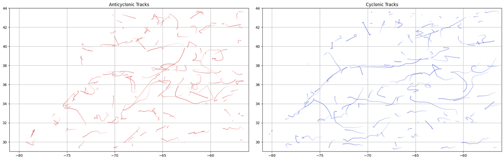

```python
import matplotlib.pyplot as plt
from matplotlib.collections import LineCollection
import numpy as np

def plot_tracks(ax, tracked, color):
    for i, _, _ in tracked.iter_on('track'):
        lon = (tracked.longitude[i] + 180) % 360 - 180
        lat = tracked.latitude[i]
        points = np.column_stack((lon, lat)).reshape(-1, 1, 2)
        segments = np.concatenate([points[:-1], points[1:]], axis=1)
        n = len(segments)
        colors = np.zeros((n, 4))
        colors[:, :3] = color
        colors[:, 3] = np.linspace(0.15, 1.0, n)  # fade in over track lifetime
        lc = LineCollection(segments, colors=colors, linewidth=0.8)
        ax.add_collection(lc)

fig, (ax1, ax2) = plt.subplots(1, 2, figsize=(20, 6))

plot_tracks(ax1, a, (0.8, 0.1, 0.1))
ax1.set_xlim(LON_RANGE)
ax1.set_ylim(LAT_RANGE)
ax1.set_aspect('equal')
ax1.set_title('Anticyclonic Tracks')
ax1.grid()

plot_tracks(ax2, c, (0.1, 0.2, 0.8))
ax2.set_xlim(LON_RANGE)
ax2.set_ylim(LAT_RANGE)
ax2.set_aspect('equal')
ax2.set_title('Cyclonic Tracks')
ax2.grid()

plt.tight_layout()
plt.show()
```

```python
from py_eddy_tracker.featured_tracking.area_tracker import AreaTracker
```

How does changing `.position_filter()` and `virtual` and other parameters affect outputs of eddy tracking?

### Isolate Longest-Lived Eddies

Filter by lifetime and plot out their tracks. Pick out a few to obtain contours over time, and then obtain a lon/lat boolean mask for their contours.

Length refers to the number of observations, which is the count of times that a specific track id appears in the track array.

Time is days since 1950-01-01. Consider each individual eddy track to be non-overlapping subarrays of time. Within each subarray, time is strictly monotonically increasing.

```python
def calendar_days_per_track(tracked: TrackEddiesObservations) -> np.ndarray:
    """
    Compute the inclusive calendar duration (in days) of each track.

    Uses the contiguous ordering of the track array to find boundaries
    between tracks, then computes duration in days per track.

    Args:
        tracked: TrackEddiesObservations with contiguous track IDs.

    Returns:
        1D array of calendar days per track, indexed by track ID.
    """
    boundaries = np.flatnonzero(np.diff(tracked.track)) + 1
    boundaries = np.concatenate([[0], boundaries, [len(tracked.track)]])
    t_start = tracked.time[boundaries[:-1]]
    t_end = tracked.time[boundaries[1:] - 1]
    return t_end - t_start + 1
```

```python
a_cal_days = calendar_days_per_track(a)
c_cal_days = calendar_days_per_track(c)

print(f"Anticyclonic: {len(a_cal_days)} tracks, longest = {a_cal_days.max()} days")
print(f"Cyclonic: {len(c_cal_days)} tracks, longest = {c_cal_days.max()} days")
```

```
Anticyclonic: 137 tracks, longest = 90.0 days
Cyclonic: 131 tracks, longest = 90.0 days
```

Find the longest-lived track IDs for each type.

```python
a_longest_ids = np.where(a_cal_days == a_cal_days.max())[0]
c_longest_ids = np.where(c_cal_days == c_cal_days.max())[0]

print(f"Longest anticyclonic track IDs: {a_longest_ids} ({a_cal_days.max()} days)")
print(f"Longest cyclonic track IDs: {c_longest_ids} ({c_cal_days.max()} days)")
```

```
Longest anticyclonic track IDs: [ 3 23] (90.0 days)
Longest cyclonic track IDs: [ 4  5 20 21 24] (90.0 days)
```

Obtain new TrackEddiesObservations objects with only the longest lived eddies

```python
a_long = a.extract_ids(a_longest_ids)
c_long = c.extract_ids(c_longest_ids)
```

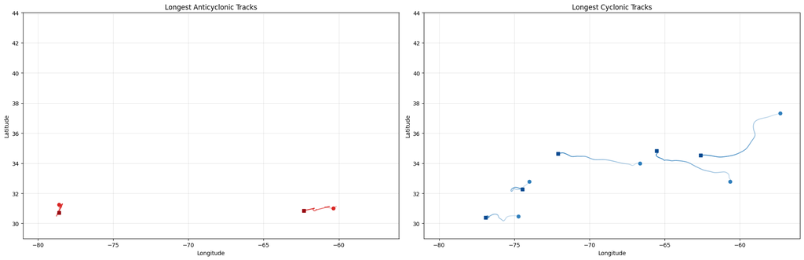

```python
fig, (ax1, ax2) = plt.subplots(1, 2, figsize=(20, 7))

for ax, tracked, title, cmap_name in [
    (ax1, a_long, 'Longest Anticyclonic Tracks', 'Reds'),
    (ax2, c_long, 'Longest Cyclonic Tracks', 'Blues'),
]:
    cmap = plt.get_cmap(cmap_name)
    unique_ids = np.unique(tracked.track)
    for track_id in unique_ids:
        eddy_mask = tracked.track == track_id
        lon = (tracked.longitude[eddy_mask] + 180) % 360 - 180
        lat = tracked.latitude[eddy_mask]

        # Fade segments from transparent to opaque over the track lifetime
        points = np.column_stack((lon, lat)).reshape(-1, 1, 2)
        segments = np.concatenate([points[:-1], points[1:]], axis=1)
        n = len(segments)
        seg_colors = np.zeros((n, 4))
        seg_colors[:, :3] = cmap(0.7)[:3]
        seg_colors[:, 3] = np.linspace(0.15, 1.0, n)
        lc = LineCollection(segments, colors=seg_colors, linewidth=1.5)
        ax.add_collection(lc)

        ax.plot(lon[0], lat[0], 'o', color=cmap(0.7), markersize=6)
        ax.plot(lon[-1], lat[-1], 's', color=cmap(0.9), markersize=6)

    ax.set_xlim(LON_RANGE)
    ax.set_ylim(LAT_RANGE)
    ax.set_aspect('equal')
    ax.set_title(title)
    ax.set_xlabel('Longitude')
    ax.set_ylabel('Latitude')
    ax.grid(alpha=0.3)

plt.tight_layout()
plt.savefig('longest_lived_tracks.png', dpi=150, bbox_inches='tight')
plt.show()
```

Plot out their contours throughout track

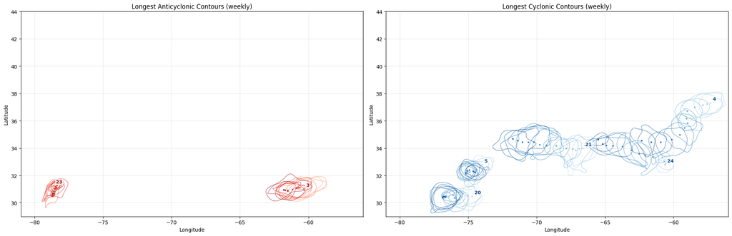

```python
def get_id_indices(tracked: TrackEddiesObservations, track_id: int) -> np.ndarray:
    """Obtain the row indices belonging to a specific track (e.g., for effective_contour_lon/lat)."""
    return np.where(tracked.track == track_id)[0]

a_longest_idxs = {} # map track id to row indices
c_longest_idxs = {}

for id in a_longest_ids:
    a_longest_idxs[id] = get_id_indices(a_long, id)
for id in c_longest_ids:
    c_longest_idxs[id] = get_id_indices(c_long, id)

# Plot contour evolution, subsampled weekly
SUBSAMPLE = 7

fig, (ax1, ax2) = plt.subplots(1, 2, figsize=(20, 7))

for ax, tracked, idxs_dict, title, cmap_name in [
    (ax1, a_long, a_longest_idxs, 'Longest Anticyclonic Contours (weekly)', 'Reds'),
    (ax2, c_long, c_longest_idxs, 'Longest Cyclonic Contours (weekly)', 'Blues'),
]:
    cmap = plt.get_cmap(cmap_name)
    for track_id, rows in idxs_dict.items():
        sampled = rows[::SUBSAMPLE]
        n_sampled = len(sampled)
        for j, i in enumerate(sampled):
            lon = (tracked.contour_lon_e[i] + 180) % 360 - 180
            lat = tracked.contour_lat_e[i]

            # Close the polygon
            lon = np.append(lon, lon[0])
            lat = np.append(lat, lat[0])

            color = cmap(0.3 + 0.6 * j / max(n_sampled - 1, 1))
            ax.plot(lon, lat, color=color, linewidth=0.8, alpha=0.7)

            # Plot eddy center
            center_lon = (tracked.longitude[i] + 180) % 360 - 180
            center_lat = tracked.latitude[i]
            ax.plot(center_lon, center_lat, '.', color=color, markersize=4)

        # Label at first contour center
        first_i = rows[0]
        label_lon = (tracked.longitude[first_i] + 180) % 360 - 180
        label_lat = tracked.latitude[first_i]
        ax.annotate(
            str(track_id), (label_lon, label_lat),
            fontsize=9, fontweight='bold', color=cmap(0.9),
            textcoords='offset points', xytext=(5, 5),
            bbox=dict(boxstyle='round,pad=0.2', fc='white', ec='none', alpha=0.7),
        )

    ax.set_xlim(LON_RANGE)
    ax.set_ylim(LAT_RANGE)
    ax.set_aspect('equal')
    ax.set_title(title)
    ax.set_xlabel('Longitude')
    ax.set_ylabel('Latitude')
    ax.grid(alpha=0.3)

plt.tight_layout()
plt.show()
```

### Overlay PACE Data

Perform quality control methods.

Raw downloaded data should be read-only.

Procedure:

Iterate through each PACE file and obtain the date from the filename. Look up long-lived eddy positions/contours on that date and check spatial overlap.

We only look at snapshots where the chosen eddy is fully within the PACE swath (all points forming contour are within swath bounds).

After identifying valid PACE pixels, SST and SSS come in. Ultimately, Rrs -> (n_samples, n_wavelengths), temp -> (n_samples), sal -> (n_samples). (lon, lat, time) gets collapsed into individual points.

```python
# Define target eddy

print(c_longest_ids)
c_eddy_id = 20 # chosen eddy id
exclude_bits = [0, 1, 3, 4, 8, 9, 14, 16, 25, 26]
```

```
[ 4  5 20 21 24]
```

```python
from scipy.spatial import ConvexHull
from matplotlib import path
import xarray as xr

def swath_contains_eddy(
    swath_lon: np.ndarray,
    swath_lat: np.ndarray,
    contour_lon: np.ndarray,
    contour_lat: np.ndarray,
) -> bool:
    """Expects 1D arrays for both swath and eddy contour points, with a 1:1 correspondance between the indices."""
    valid = ~np.isnan(swath_lon) & ~np.isnan(swath_lat)
    hull_points = np.column_stack([swath_lon[valid], swath_lat[valid]])

    # Guard against so few valid points that a polygon cannot be formed
    if hull_points.shape[0] < 3:
        return False

    hull = ConvexHull(hull_points)
    hull_polygon = path.Path(hull_points[hull.vertices])

    eddy_boundary = np.column_stack([contour_lon, contour_lat])
    return bool(np.all(hull_polygon.contains_points(eddy_boundary)))


def extract_valid_pixels(
    swath_lon: np.ndarray,
    swath_lat: np.ndarray,
    swath_rrs: np.ndarray,
    swath_flags: np.ndarray,
    contour_lon: np.ndarray,
    contour_lat: np.ndarray,
    exclude_mask: int,
    min_coverage: float = 0.5,
) -> dict | None:
    """
    Extract QC-filtered Rrs pixels within an eddy contour. Flattens and reshapes swath data if necessary.
        - Expects rrs to be of same shape as lon/lat, with 1 extra channel for all wavelengths.
        - Expects contour lon/lat to be 1D arrays
        - Expects exclude_mask as a precomputed integer bitmask (not a list of bits).

    Returns dict with 'rrs', 'lon', 'lat', 'qc_fraction', or None if coverage < min_coverage. All points outside of the eddy contour or containing an invalid QC flag are removed.
    """
    N = swath_lon.size
    lon_flat = swath_lon.ravel()
    lat_flat = swath_lat.ravel()
    rrs_flat = swath_rrs.reshape(N, -1) # (n_obs, n_wavelengths)
    flags_flat = swath_flags.ravel()

    polygon = path.Path(np.column_stack([contour_lon, contour_lat]))
    points = np.column_stack([lon_flat, lat_flat])

    inside = polygon.contains_points(points)
    qc_good = (flags_flat & exclude_mask) == 0
    valid = inside & qc_good

    n_inside = np.sum(inside)
    n_valid = np.sum(valid)

    if n_inside == 0:
        return None

    qc_fraction = n_valid / n_inside
    if qc_fraction < min_coverage:
        return None

    return {
        'rrs': rrs_flat[valid],
        'lon': lon_flat[valid],
        'lat': lat_flat[valid],
        'qc_fraction': float(qc_fraction),
    }
```

```python
# Build a table of each valid pixel from every PACE swath which fully contains target eddy.
# Columns: track_id, date, lon, lat, qc_fraction, Rrs_<wavelength>...

import datetime as dt
import pandas as pd

PACE_DIR = Path('/Users/jerry/Desktop/school/research/eddy-tracking/data/pace_oci_gulf_stream_20250101_20250331')
MIN_COVERAGE = 0.8

rrs_fp = Path('/Users/jerry/Desktop/school/research/eddy-tracking/data') / f'eddy_{c_eddy_id}_rrs.csv'

if rrs_fp.exists():
    inputs_df = pd.read_csv(rrs_fp, parse_dates=['date'])
    print(f"Loaded cached CSV: {len(inputs_df)} rows")
else:
    # Precompute integer bitmask from exclude_bits
    exclude_mask = 0
    for bit in exclude_bits:
        exclude_mask |= (1 << bit)

    # Eddy contour data for the chosen track
    # PET uses 0-360 longitude; PACE uses -180 to 180, so convert here
    eddy_mask = c_long.track == c_eddy_id
    eddy_lons = (c_long.contour_lon_e[eddy_mask] + 180) % 360 - 180
    eddy_lats = c_long.contour_lat_e[eddy_mask]
    eddy_times = c_long.time[eddy_mask]
    times_set = set(eddy_times)

    wavelengths = np.load('/Users/jerry/Desktop/school/research/eddy-tracking/data/pace_wavelengths.npy')
    rrs_cols = [f'Rrs_{w}' for w in wavelengths]

    base = dt.datetime(1950, 1, 1)
    row_chunks = []

    for fp in sorted(glob(f"{PACE_DIR}/*.nc")):
        pace_time = dt.datetime.strptime(fp.split('.')[1], '%Y%m%dT%H%M%S')
        pace_time_pet = (pace_time - base).days # PET stores time in days since 1950-01-01

        # Match up so that rrs data is on the same day as eddy
        if pace_time_pet not in times_set:
            continue

        same_day_idx = np.flatnonzero(eddy_times == pace_time_pet)[0]

        with xr.open_dataset(fp) as ds:
            swath_lon = ds['longitude'].to_numpy()
            swath_lat = ds['latitude'].to_numpy()

            # Only consider the data granule if the eddy is completely covered
            if not swath_contains_eddy(
                swath_lon.ravel(), swath_lat.ravel(),
                eddy_lons[same_day_idx], eddy_lats[same_day_idx],
            ):
                continue

            # Obtain dictionary of data_var: observations array
            result = extract_valid_pixels(
                swath_lon,
                swath_lat,
                ds['Rrs'].to_numpy(),
                ds['l2_flags'].to_numpy(),
                eddy_lons[same_day_idx],
                eddy_lats[same_day_idx],
                exclude_mask,
                min_coverage=MIN_COVERAGE,
            )

        if result is None:
            continue

        n = len(result['lon'])
        chunk = np.column_stack([
            np.full(n, c_eddy_id),
            np.full(n, pace_time_pet),
            result['lon'],
            result['lat'],
            np.full(n, result['qc_fraction']),
            result['rrs'],
        ])
        row_chunks.append(chunk)
        print(f"{pace_time.date()}: {n} valid points, qc={result['qc_fraction']}")

    # Save the data to disk
    all_data = np.vstack(row_chunks)

    columns = ['track_id', 'date', 'lon', 'lat', 'qc_fraction'] + rrs_cols

    inputs_df = pd.DataFrame(all_data, columns=columns)
    inputs_df['track_id'] = inputs_df['track_id'].astype(int)
    inputs_df['date'] = pd.Timestamp('1950-01-01') + pd.to_timedelta(inputs_df['date'], unit='D')

    print(f"Total: {len(inputs_df)} pixels, {len(row_chunks)} data granules")
    print(inputs_df.head())

    inputs_df.to_csv(rrs_fp)
```

```
Loaded cached CSV: 103487 rows
```

Now that we have Rrs, we need to pre-process it for the SDP model. QC filtering has been done already. Next, we need to:

1. Interpolate to 1 nm (at an padded range of 396-704 nm)
2. 5 nm moving mean smoothing
3. Trim the edges 4 nm on either side

```python
from utils.sdp.preprocessing import preprocess_rrs_batch

wavelengths = np.load('data/pace_wavelengths.npy')
rrs_cols = [col for col in inputs_df.columns if col.startswith('Rrs_')]
rrs_raw = inputs_df[rrs_cols].values  # shape: (n_pixels, n_wavelengths)

# Preprocess: interpolate to 1 nm, smooth with 5 nm moving mean, trim edges
# wavelengths is [400, 700]
# rrs_preprocessed is table of observations with interpolated rrs
wavelengths, rrs_processed = preprocess_rrs_batch(wavelengths, rrs_raw)

print(f"Input shape: {rrs_raw.shape}")
print(f"Output shape: {rrs_processed.shape}")

# Check for all NaN rows
n_invalid = np.isnan(rrs_processed).any(axis=1).sum()
if n_invalid > 0:
    raise ValueError("error")

# If this runs properly, then there should be 0 NaN values in Rrs
```

```
Input shape: (103487, 172)
Output shape: (103487, 301)
```

Now that we have the matched table of PACE and eddy, obtain SSS and SST at each (lon, lat, date) to add matched `temp` and `sal` columns.

```python
from utils.sdp.ancillary import load_sst_dataset, load_sss_dataset, sample_ancillary

SST_DIR = Path('data/sst_gulf_stream_20250101_20250331')
SSS_DIR = Path('data/sss_gulf_stream_20250101_20250331')

# Load all gridded files into DataArrays with a time dimension
sst_da = load_sst_dataset(SST_DIR)
sss_da = load_sss_dataset(SSS_DIR)
print(f"SST: {sst_da.sizes}")
print(f"SSS: {sss_da.sizes}")

# Obtain corresponding (lon, lat, date) points from SSS/SST data
sst_vals, sss_vals = sample_ancillary(
    sst_da, sss_da,
    inputs_df['lon'].values,
    inputs_df['lat'].values,
    inputs_df['date'].values,
)

# Add to data
inputs_df['sst'] = sst_vals
inputs_df['sss'] = sss_vals

# Check for NaN values
n_missing_sst = np.isnan(sst_vals).sum()
n_missing_sss = np.isnan(sss_vals).sum()
print(f"SST missing: {n_missing_sst}/{len(sst_vals)}")
print(f"SSS missing: {n_missing_sss}/{len(sss_vals)}")

# Drop rows with NaN values
valid_mask = (
    ~np.isnan(rrs_processed).any(axis=1)
    & np.isfinite(inputs_df['sst'].values)
    & np.isfinite(inputs_df['sss'].values)
)
print(f"Valid rows: {valid_mask.sum()}/{len(valid_mask)}")

# Also need to prevent any NaNs in SSS/SST -> propagates throughout model residual calculations
inputs_df['qc_fraction']
```

```
SST: Frozen({'time': 12, 'lat': 360, 'lon': 600})
SSS: Frozen({'time': 96, 'latitude': 60, 'longitude': 100})
SST missing: 0/103487
SSS missing: 0/103487
Valid rows: 103487/103487
```

```
0         0.995606
1         0.995606
2         0.995606
3         0.995606
4         0.995606
            ...
103482    0.989171
103483    0.989171
103484    0.989171
103485    0.989171
103486    0.989171
Name: qc_fraction, Length: 103487, dtype: float64
```

Obtain residuals and run the PCR for pigments

```python
from utils.sdp import run_sdp

pigments_fp = Path('data') / f'eddy_{c_eddy_id}_pigments.csv'

if pigments_fp.exists():
    pigments_df = pd.read_csv(pigments_fp)
    print(f"Loaded saved pigments: {pigments_df.shape}")
else:
    # Build Rrs DataFrame with integer wavelength columns which is what's expected as model input
    wl_int = wavelengths.astype(int)
    rrs_df = pd.DataFrame(rrs_processed[valid_mask], columns=wl_int)

    # Run SDP model: GSM inversion -> residuals -> 2nd derivative -> PCR
    pigments_df = run_sdp(
        rrs=rrs_df,
        wl=wavelengths,
        sst=inputs_df.loc[valid_mask, 'sst'].to_numpy(),
        sss=inputs_df.loc[valid_mask, 'sss'].to_numpy(),
    )

    pigments_df.to_csv(pigments_fp, index=False)
    print(f"Saved pigments to {pigments_fp}")

print(f"Pigment predictions: {pigments_df.shape}")
print(pigments_df)
```

```
Loaded saved pigments: (103487, 13)
Pigment predictions: (103487, 13)
          T chla       Zea   DV chla   ButFuco   HexFuco      Allo   MV chlb  \
0       0.168189  0.021938  0.044928  0.024148  0.095536  0.015332  0.050506
1       0.455448  0.022030  0.021791  0.035224  0.152629  0.037734  0.120933
2       0.000000  0.000000  0.015222  0.017167  0.055094  0.007187  0.018438
3       0.421369  0.066426  0.026429  0.024311  0.117242  0.009275  0.047892
4       0.552136  0.061401  0.033385  0.031799  0.116401  0.026172  0.094142
...          ...       ...       ...       ...       ...       ...       ...
103482  0.000000  0.006256  0.053063  0.014671  0.047339  0.004342  0.018353
103483  0.704082  0.020678  0.030788  0.046500  0.179449  0.033603  0.107445
103484  0.261914  0.000000  0.000000  0.024221  0.098610  0.016001  0.050273
103485  0.000000  0.019920  0.041398  0.000000  0.000000  0.000000  0.000000
103486  0.000000  0.048706  0.080411  0.002011  0.000000  0.000587  0.026368

             Neo     Viola      Fuco  chl c1+c2    chl c3     Perid
0       0.006267  0.010588  0.000000   0.021378  0.022421  0.008476
1       0.016138  0.025555  0.011159   0.049453  0.057611  0.002423
2       0.001742  0.003420  0.000000   0.000000  0.009723  0.000000
3       0.003105  0.006284  0.126831   0.054690  0.049456  0.030049
4       0.011983  0.017772  0.066425   0.069348  0.044620  0.014129
...          ...       ...       ...        ...       ...       ...
103482  0.000299  0.003193  0.000000   0.000000  0.000000  0.003650
103483  0.014252  0.020031  0.123695   0.107774  0.079929  0.012937
103484  0.005994  0.010193  0.017200   0.039288  0.036739  0.005994
103485  0.000000  0.000000  0.000000   0.000000  0.000000  0.008292
103486  0.000000  0.002259  0.000000   0.000000  0.000000  0.009741

[103487 rows x 13 columns]
```

Display the predicted pigments

```python
# Add time and location context to pigment (rows align with inputs_df)
pigments_df['lon']  = inputs_df.loc[valid_mask, 'lon'].values
pigments_df['lat']  = inputs_df.loc[valid_mask, 'lat'].values
pigments_df['date'] = inputs_df.loc[valid_mask, 'date'].values

pigments_df.info()
```

```
<class 'pandas.core.frame.DataFrame'>
RangeIndex: 103487 entries, 0 to 103486
Data columns (total 16 columns):
 #   Column     Non-Null Count   Dtype
---  ------     --------------   -----
 0   T chla     103487 non-null  float64
 1   Zea        103487 non-null  float64
 2   DV chla    103487 non-null  float64
 3   ButFuco    103487 non-null  float64
 4   HexFuco    103487 non-null  float64
 5   Allo       103487 non-null  float64
 6   MV chlb    103487 non-null  float64
 7   Neo        103487 non-null  float64
 8   Viola      103487 non-null  float64
 9   Fuco       103487 non-null  float64
 10  chl c1+c2  103487 non-null  float64
 11  chl c3     103487 non-null  float64
 12  Perid      103487 non-null  float64
 13  lon        103487 non-null  float64
 14  lat        103487 non-null  float64
 15  date       103487 non-null  datetime64[ns]
dtypes: datetime64[ns](1), float64(15)
memory usage: 12.6 MB
```

### Check whether the values predicted from SDP model make sense.

First check whether the relationship between predicted values makes sense.

Use DPA framework to estimate the contribution of each major phytoplankton group to total chlorophyll a, using significant accessory pigments with empiricle weights.

[figure not shown]

```
         date  n_pixels  mean_chla_sdp  mean_chla_dpa  median_chla_sdp  \
0  2025-01-29      7671       0.233176       0.248011         0.155965
1  2025-01-30     11865       0.285010       0.280505         0.266055
2  2025-02-10      4222       0.287796       0.259154         0.261208
3  2025-02-13      5432       0.139762       0.153989         0.066991
4  2025-02-28     12812       0.210901       0.205715         0.165051
5  2025-03-12      9596       0.270310       0.272106         0.242833
6  2025-03-18      9238       0.279171       0.279115         0.261217
7  2025-03-19     25779       0.489966       0.447999         0.401419
8  2025-03-20      8558       0.190326       0.199650         0.145364
9  2025-03-26      8314       0.235881       0.234301         0.191870

   median_chla_dpa
0         0.209789
1         0.262608
2         0.234780
3         0.112481
4         0.169914
5         0.244982
6         0.256438
7         0.376280
8         0.170504
9         0.202813
```

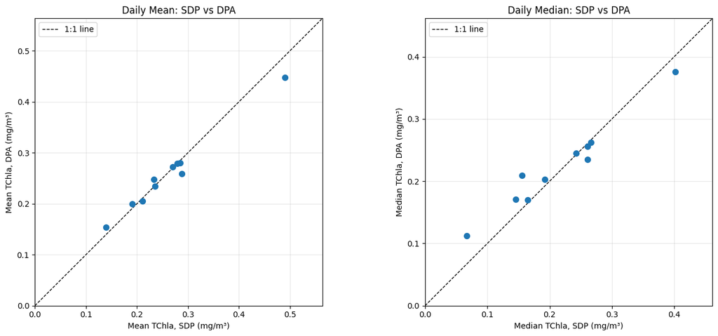

```python
# Uitz diagnostic pigment analysis
# TChla = 1.41*Fuco + 1.41*Perid + 1.27*HexFuco + 0.35*ButFuco + 0.60*Allo  + 1.01*TChlb + 0.86*Zea

DPA_WEIGHTS = {
    'Fuco':    1.41,
    'Perid':   1.41,
    'HexFuco': 1.27,
    'ButFuco': 0.35,
    'Allo':    0.60,
    'MV chlb': 1.01, # use in place of TChlb
    'Zea':     0.86,
}

tchla_pred = sum(pigments_df[pig] * w for pig, w in DPA_WEIGHTS.items())
diffs = tchla_pred - pigments_df['T chla']

# Build a per-day comparison
rows = []
dates = pigments_df['date'].dt.date
unique_dates = sorted(dates.unique())

for d in unique_dates:
    mask = (dates == d)

    row = {
        'date': d,
        'n_pixels': mask.sum(),
        'mean_chla_sdp': pigments_df.loc[mask, 'T chla'].mean(),
        'mean_chla_dpa': tchla_pred[mask].mean(),
        'median_chla_sdp': pigments_df.loc[mask, 'T chla'].median(),
        'median_chla_dpa': tchla_pred[mask].median()
    }
    rows.append(row)

dpa_df = pd.DataFrame(rows)
print(dpa_df)

fig, (ax1, ax2) = plt.subplots(1, 2, figsize=(14, 6))

for ax, sdp_col, dpa_col, stat in [
    (ax1, 'mean_chla_sdp', 'mean_chla_dpa', 'Mean'),
    (ax2, 'median_chla_sdp', 'median_chla_dpa', 'Median'),
]:
    ax.scatter(dpa_df[sdp_col], dpa_df[dpa_col], s=50, zorder=3)

    # 1:1 reference line
    lim = max(dpa_df[sdp_col].max(), dpa_df[dpa_col].max()) * 1.15
    ax.plot([0, lim], [0, lim], 'k--', linewidth=1, label='1:1 line')

    ax.set(xlabel=f'{stat} TChla, SDP (mg/m³)',
           ylabel=f'{stat} TChla, DPA (mg/m³)',
           title=f'Daily {stat}: SDP vs DPA',
           xlim=(0, lim), ylim=(0, lim))
    ax.set_aspect('equal')
    ax.legend()
    ax.grid(alpha=0.3)

plt.tight_layout()
plt.show()
```

Check the fraction of zeros after running the model, since negative values are clipped to zero.

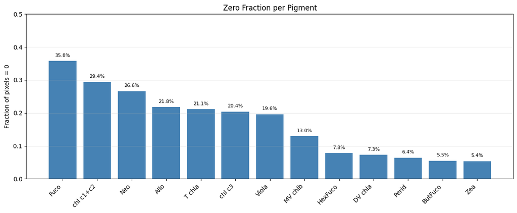

```python
# Fraction of zeros per pigment
# Negative SDP predictions are clipped to 0, so a high zero fraction signals
# frequent unphysical (negative) model outputs for that pigment.

pigment_cols = [c for c in pigments_df.columns if c not in ['lon', 'lat', 'date']]
zero_frac = (pigments_df[pigment_cols] == 0).mean().sort_values(ascending=False)

fig, ax = plt.subplots(figsize=(12, 5))
bars = ax.bar(range(len(zero_frac)), zero_frac.values, color='steelblue')
ax.set_xticks(range(len(zero_frac)))
ax.set_xticklabels(zero_frac.index, rotation=45, ha='right')
ax.set(ylabel='Fraction of pixels = 0', title='Zero Fraction per Pigment', ylim=(0, 0.5))
ax.grid(alpha=0.3, axis='y')

# Annotate each bar with the percentage
for i, (name, frac) in enumerate(zero_frac.items()):
    ax.text(i, frac + 0.01, f'{frac:.1%}', ha='center', va='bottom', fontsize=8)

plt.tight_layout()
plt.show()
```

Check pigment ratio to total chlorophyll a and whether that matches with literature.

```
   Pigment  Group                Model Median         Model IQR   Range from Lit.
--------------------------------------------------------------------------------
     Perid  Dinoflagellates             0.033  [0.018, 0.062]  [0.010, 0.05]
      Fuco  Diatoms                     0.171  [0.060, 0.245]  [0.050, 0.30]
       Zea  Cyanobacteria               0.130  [0.079, 0.239]  [0.050, 0.30]
   DV chla  Prochlorococcus             0.099  [0.045, 0.216]  [0.100, 0.40]
    chl c3  Haptophytes                 0.093  [0.083, 0.105]  [0.020, 0.15]
   HexFuco  Haptophytes                 0.255  [0.207, 0.352]  [0.100, 0.40]
   MV chlb  Green algae                 0.138  [0.098, 0.189]  [0.000, 0.15]
```

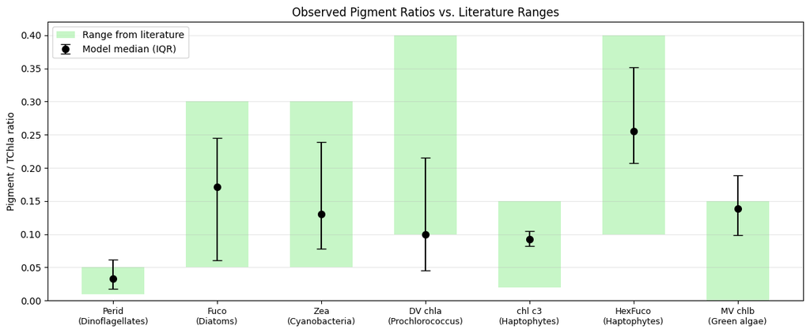

```python
# Pigment-to-TChla ratios vs. literature ranges.
#
# No single paper publishes "acceptable ranges" for all pigment/TChla ratios.
# For the 7 DPA pigments, ranges are constructed from site-specific medians
# in Kramer & Siegel (2019) Table 2 at BOUSSOLE (oligotrophic Med) and
# CARIACO (tropical Caribbean), padded outward for Gulf Stream variability.
# For the remaining pigments, ranges come from broader literature.
#
# Sources:
#   [1] Kramer & Siegel (2019) https://pmc.ncbi.nlm.nih.gov/articles/PMC7043335/
#   [2] Kramer et al. (2020) https://doi.org/10.3389/fmars.2020.00215
#   [3] Goericke & Repeta (1992) DVchla in subtropical N. Atlantic
#   [4] Higgins et al. (2011) Phytoplankton Pigments, Cambridge Univ. Press
#   [5] Aiken et al. (2009) https://doi.org/10.1016/j.dsr2.2008.09.017

LITERATURE = {
    'Perid':     {'range': (0.01, 0.05), 'group': 'Dinoflagellates'},    # regional [1]: BOUS 0.019, CAR 0.023; global 0.017
    'Fuco':      {'range': (0.05, 0.30), 'group': 'Diatoms'},           # regional [1]: BOUS 0.056, CAR 0.065; global 0.140
    'Zea':       {'range': (0.05, 0.30), 'group': 'Cyanobacteria'},     # regional [1]: BOUS 0.134, CAR 0.294
    'DV chla':   {'range': (0.10, 0.40), 'group': 'Prochlorococcus'},   # regional [3]: up to 40% of TChla, subtropical N. Atl
    'chl c3':    {'range': (0.02, 0.15), 'group': 'Haptophytes'},       # global [4,5]: CHEMTAX ratio matrices
    'HexFuco':   {'range': (0.10, 0.40), 'group': 'Haptophytes'},       # regional [1]: BOUS 0.253, CAR 0.102
    'MV chlb':   {'range': (0.00, 0.15), 'group': 'Green algae'},       # regional [1]: BOUS 0.000, CAR 0.046; global 0.045
}

# Compute observed ratios (exclude TChla == 0 pixels)
valid = pigments_df['T chla'] > 0
ratios = {}
for pig in LITERATURE:
    ratios[pig] = pigments_df.loc[valid, pig] / pigments_df.loc[valid, 'T chla']

# --- Summary table ---
print(f"{'Pigment':>10s}  {'Group':<18s}  {'Model Median':>13s}  {'Model IQR':>16s}  "
      f"{'Range from Lit.':>16s}")
print('-' * 80)

for pig, info in LITERATURE.items():
    r = ratios[pig]
    med = r.median()
    q25, q75 = r.quantile(0.25), r.quantile(0.75)
    lo, hi = info['range']

    print(f'{pig:>10s}  {info["group"]:<18s}  {med:13.3f}  [{q25:.3f}, {q75:.3f}]  '
          f'[{lo:.3f}, {hi:.2f}]')

# --- Bar chart: observed median vs literature range ---
fig, ax = plt.subplots(figsize=(12, 5))
names = list(LITERATURE.keys())
x = np.arange(len(names))

lows = [LITERATURE[p]['range'][0] for p in names]
highs = [LITERATURE[p]['range'][1] for p in names]
ax.bar(x, [h - l for h, l in zip(highs, lows)], bottom=lows,
       width=0.6, color='lightgreen', alpha=0.5, label='Range from literature')

medians = [ratios[p].median() for p in names]
q25s = [ratios[p].quantile(0.25) for p in names]
q75s = [ratios[p].quantile(0.75) for p in names]
ax.errorbar(x, medians, yerr=[[m - q for m, q in zip(medians, q25s)],
                               [q - m for m, q in zip(medians, q75s)]],
            fmt='o', color='black', capsize=5, markersize=7, label='Model median (IQR)')

ax.set_xticks(x)
ax.set_xticklabels([f'{n}\n({LITERATURE[n]["group"]})' for n in names], fontsize=9)
ax.set(ylabel='Pigment / TChla ratio', title='Observed Pigment Ratios vs. Literature Ranges')
ax.legend()
ax.grid(alpha=0.3, axis='y')
plt.tight_layout()
plt.show()
```

View how numerical values of pigments change over time.

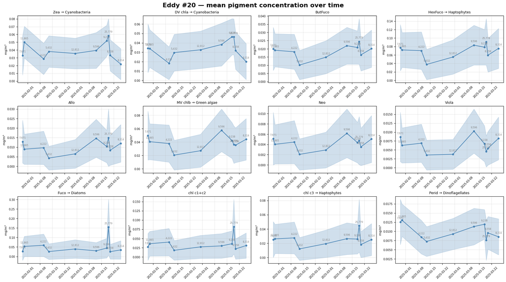

```
Date            n_pixels         Zea     DV chla     ButFuco     HexFuco        Allo     MV chlb         Neo       Viola        Fuco   chl c1+c2      chl c3       Perid
------------------------------------------------------------------------------------------------------------------------------------------------------------------------
2025-01-29         7,671      0.0330      0.0342      0.0199      0.0772      0.0129      0.0496      0.0051      0.0086      0.0277      0.0271      0.0251      0.0125
2025-01-30        11,865      0.0501      0.0340      0.0191      0.0719      0.0089      0.0404      0.0040      0.0063      0.0531      0.0358      0.0261      0.0130
2025-02-10         4,222      0.0286      0.0183      0.0182      0.0703      0.0097      0.0376      0.0045      0.0069      0.0591      0.0402      0.0275      0.0084
2025-02-13         5,432      0.0380      0.0296      0.0101      0.0376      0.0043      0.0204      0.0021      0.0036      0.0260      0.0179      0.0120      0.0073
2025-02-28        12,812      0.0355      0.0326      0.0149      0.0551      0.0065      0.0269      0.0029      0.0038      0.0396      0.0273      0.0193      0.0093
2025-03-12         9,596      0.0394      0.0382      0.0219      0.0833      0.0147      0.0574      0.0062      0.0103      0.0298      0.0299      0.0264      0.0113
2025-03-18         9,238      0.0518      0.0464      0.0208      0.0783      0.0104      0.0421      0.0044      0.0067      0.0442      0.0359      0.0258      0.0119
2025-03-19        25,779      0.0584      0.0464      0.0244      0.0910      0.0150      0.0361      0.0047      0.0046      0.1542      0.0820      0.0446      0.0076
2025-03-20         8,558      0.0331      0.0317      0.0163      0.0595      0.0084      0.0352      0.0035      0.0055      0.0254      0.0217      0.0181      0.0096
2025-03-26         8,314      0.0218      0.0200      0.0201      0.0755      0.0120      0.0440      0.0050      0.0082      0.0347      0.0308      0.0251      0.0085
```

```python
# --- Compute mean pigment concentration per date ---
_pig_cols = [
    c for c in pigments_df.columns if c not in ("T chla", "lon", "lat", "date")
]

_dates = pd.to_datetime(pigments_df["date"])
_grouped = pigments_df.groupby(_dates.dt.date)
_daily_mean = _grouped[_pig_cols].mean()
_daily_std = _grouped[_pig_cols].std()
_daily_count = _grouped[_pig_cols[0]].count()

_PFT_MAP = {
    "Perid":   "Dinoflagellates",
    "Fuco":    "Diatoms",
    "Zea":     "Cyanobacteria",
    "DV chla": "Cyanobacteria",
    "chl c3":  "Haptophytes",
    "HexFuco": "Haptophytes",
    "MV chlb": "Green algae",
}

# --- 3x4 grid: one time series per pigment ---
fig, axes = plt.subplots(3, 4, figsize=(18, 10), constrained_layout=True)
fig.suptitle(
    f"Eddy #{c_eddy_id} — mean pigment concentration over time",
    fontsize=16, fontweight="bold",
)

for i, pig in enumerate(_pig_cols):
    ax = axes.flat[i]
    x = _daily_mean.index
    y = _daily_mean[pig].values
    err = _daily_std[pig].values

    ax.fill_between(x, y - err, y + err, alpha=0.25, color="steelblue")
    ax.plot(x, y, "o-", color="steelblue", markersize=4, linewidth=1.5)

    # Label with PFT if diagnostic
    label = pig
    if pig in _PFT_MAP:
        label += f" \u2192 {_PFT_MAP[pig]}"
    ax.set_title(label, fontsize=9)

    ax.set_ylabel("mg/m\u00b3", fontsize=8)
    ax.tick_params(labelsize=7)
    ax.tick_params(axis="x", rotation=45)
    ax.grid(alpha=0.3)

    # Annotate pixel count on top of each point
    for xi, yi, n in zip(x, y, _daily_count.values):
        ax.annotate(f"{n:,}", (xi, yi), textcoords="offset points",
                    xytext=(0, 8), fontsize=6, ha="center", color="gray")

plt.show()

# --- Print summary table ---
print(f"\n{'Date':<14s}  {'n_pixels':>8s}", end="")
for pig in _pig_cols:
    print(f"  {pig:>10s}", end="")
print()
print("-" * (24 + 12 * len(_pig_cols)))
for date in _daily_mean.index:
    n = _daily_count.loc[date]
    print(f"{str(date):<14s}  {n:>8,d}", end="")
    for pig in _pig_cols:
        print(f"  {_daily_mean.loc[date, pig]:>10.4f}", end="")
    print()
```

View relative concentrations of various pigments within eddy over time.

```
Eddy #20 — snapshot dates: ['2025-01-30', '2025-02-28', '2025-03-12', '2025-03-19']
Pixels per date:
date
2025-01-30    11865
2025-02-28    12812
2025-03-12     9596
2025-03-19    25779
```

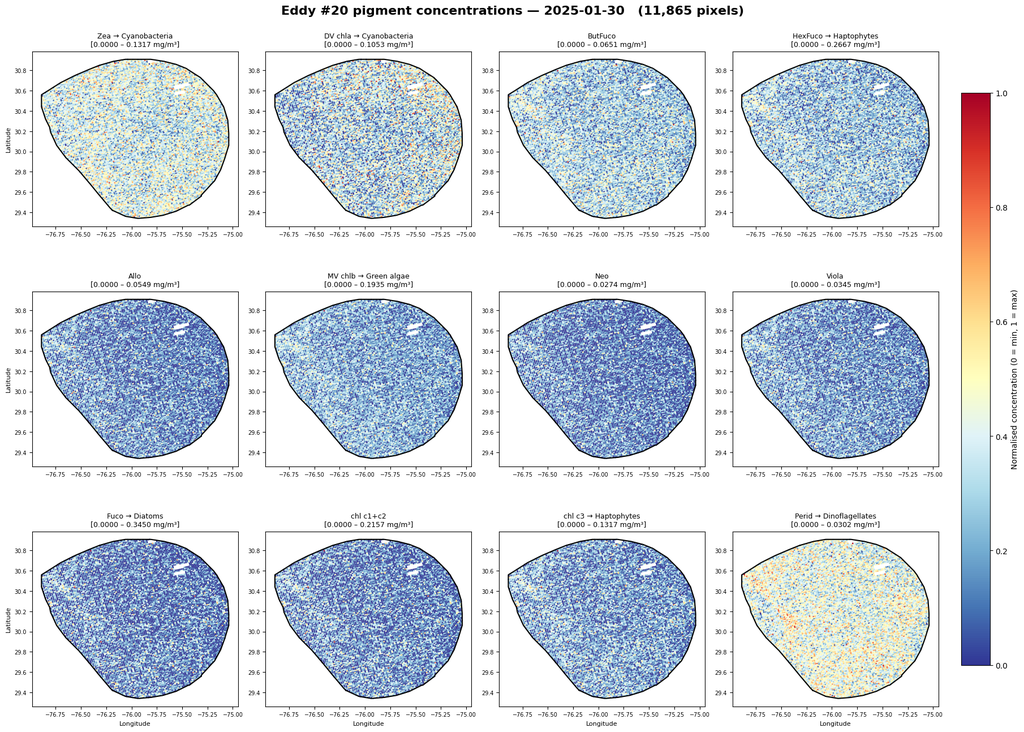

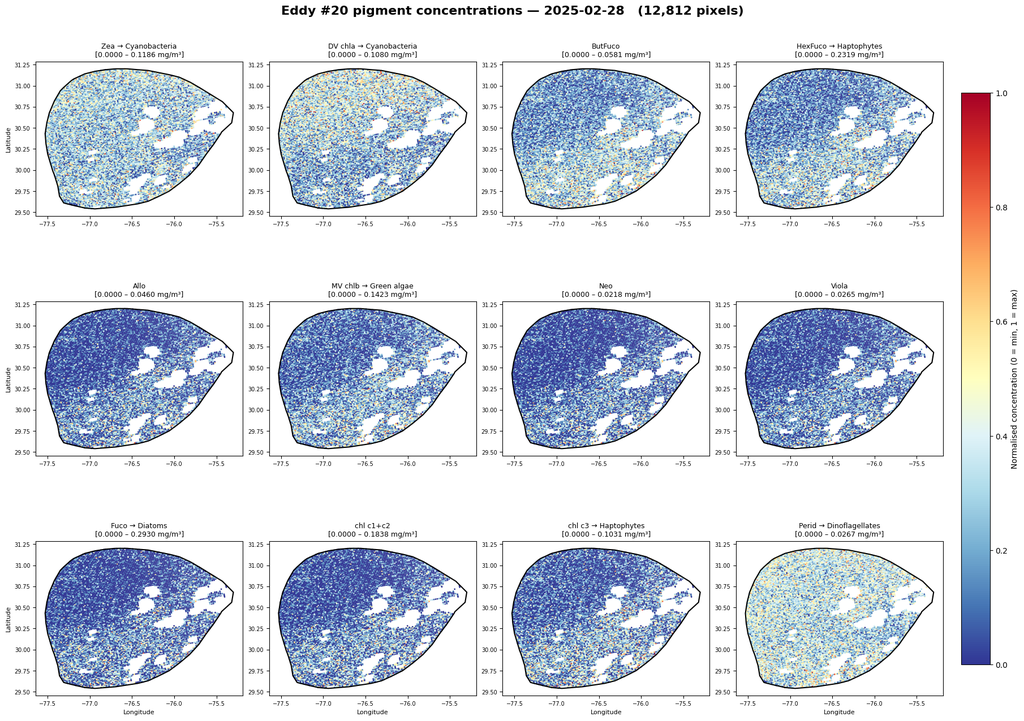

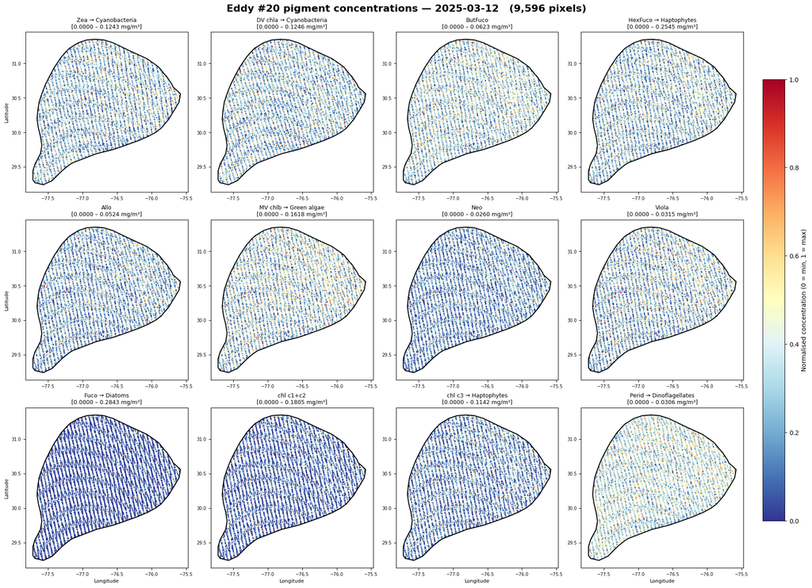

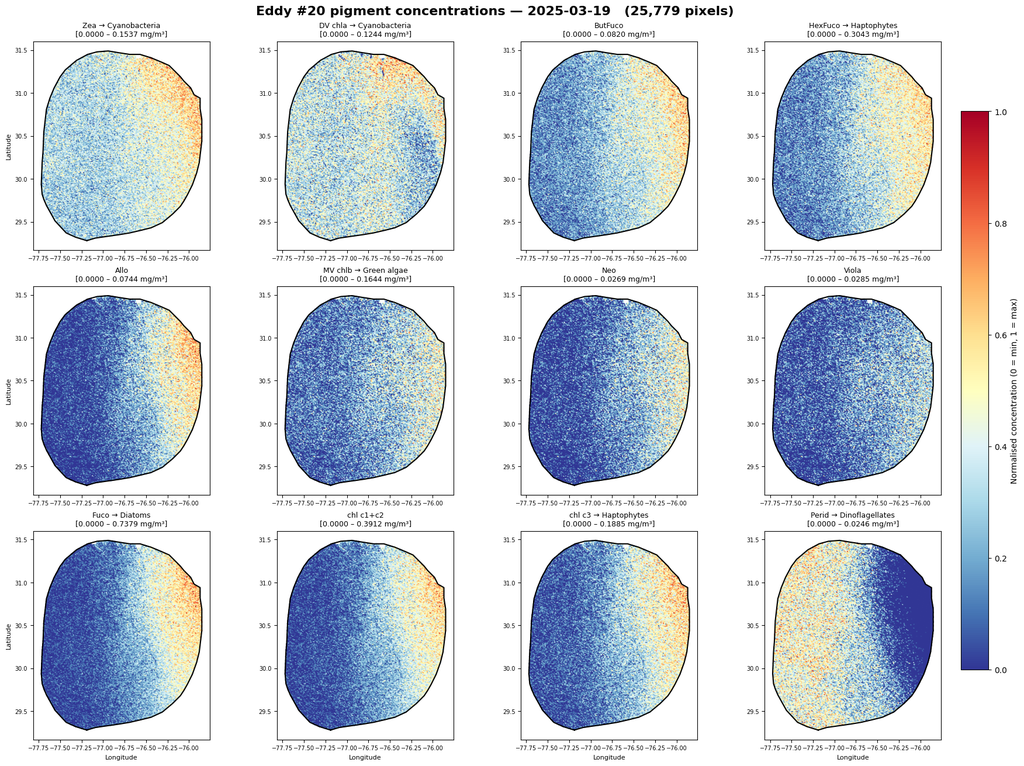

```python
"""
12-panel pigment maps inside the eddy contour for snapshot dates.

Each subplot shows one pigment's concentration as a scatter of PACE pixels,
min–max normalised to [0, 1] so spatial *patterns* are comparable across
pigments despite very different absolute magnitudes.  The actual eddy
effective-contour polygon (not a circle) is overlaid in black.
"""

from datetime import datetime as _dt, timedelta as _td

# --- Load pixel metadata directly from the Rrs CSV ---
_pixel_meta = pd.read_csv(
    f"data/eddy_{c_eddy_id}_rrs.csv",
    usecols=["date", "lon", "lat"],
)

# --- Eddy contour lookup ---
_eddy_mask = c_long.track == c_eddy_id
_eddy_clons = (c_long.contour_lon_e[_eddy_mask] + 180) % 360 - 180
_eddy_clats = c_long.contour_lat_e[_eddy_mask]
_eddy_times = c_long.time[_eddy_mask]

_PET_EPOCH = _dt(1950, 1, 1)
_date_to_idx = {
    (_PET_EPOCH + _td(days=int(t))).strftime("%Y-%m-%d"): i
    for i, t in enumerate(_eddy_times)
}

# --- Auto-select 4 snapshot dates with best pixel coverage ---
_date_counts = _pixel_meta["date"].value_counts()
_available = _date_counts.sort_index()

_N_SNAPSHOTS = 4

if len(_available) <= _N_SNAPSHOTS:
    SNAPSHOT_DATES = _available.index.tolist()
else:
    _sorted_dates = _available.index.tolist()
    _n = len(_sorted_dates)
    _quarters = [
        _sorted_dates[i * _n // _N_SNAPSHOTS : (i + 1) * _n // _N_SNAPSHOTS]
        for i in range(_N_SNAPSHOTS)
    ]
    SNAPSHOT_DATES = [
        _date_counts[chunk].idxmax() for chunk in _quarters if len(chunk) > 0
    ]

print(f"Eddy #{c_eddy_id} — snapshot dates: {SNAPSHOT_DATES}")
print(f"Pixels per date:\n{_date_counts[SNAPSHOT_DATES].to_string()}")

# 12 accessory pigment columns (exclude T chla)
PIGMENT_COLS = [
    col for col in pigments_df.columns
    if col not in ("T chla", "lon", "lat", "date")
]

# Key diagnostic pigment → PFT mapping (from clustering analysis)
PFT_MAP = {
    "Perid":   "Dinoflagellates",
    "Fuco":    "Diatoms",
    "Zea":     "Cyanobacteria",
    "DV chla": "Cyanobacteria",
    "chl c3":  "Haptophytes",
    "HexFuco": "Haptophytes",
    "MV chlb": "Green algae",
}

# --- Generate one figure per snapshot date ---
for date_str in SNAPSHOT_DATES:
    day_mask = _pixel_meta["date"] == date_str
    day_pig = pigments_df.loc[day_mask]
    day_meta = _pixel_meta.loc[day_mask]
    n_pixels = day_mask.sum()

    cidx = _date_to_idx[date_str]
    clon = _eddy_clons[cidx]
    clat = _eddy_clats[cidx]
    clon_closed = np.append(clon, clon[0])
    clat_closed = np.append(clat, clat[0])

    fig, axes = plt.subplots(3, 4, figsize=(18, 13), constrained_layout=True)
    fig.suptitle(
        f"Eddy #{c_eddy_id} pigment concentrations — {date_str}   "
        f"({n_pixels:,} pixels)",
        fontsize=16,
        fontweight="bold",
    )

    axes_flat = axes.flatten()

    for i, pigment in enumerate(PIGMENT_COLS):
        ax = axes_flat[i]
        vals = day_pig[pigment].values

        vmin, vmax = vals.min(), vals.max()
        if vmax - vmin > 0:
            norm_vals = (vals - vmin) / (vmax - vmin)
        else:
            norm_vals = np.full_like(vals, 0.5)

        sc = ax.scatter(
            day_meta["lon"].values,
            day_meta["lat"].values,
            c=norm_vals,
            cmap="RdYlBu_r",
            s=1.0,
            vmin=0,
            vmax=1,
            rasterized=True,
        )

        ax.plot(clon_closed, clat_closed, color="black", linewidth=1.5)

        # Build title: pigment name + PFT label if it's a key diagnostic pigment
        label = pigment
        if pigment in PFT_MAP:
            label += f" → {PFT_MAP[pigment]}"
        ax.set_title(f"{label}\n[{vmin:.4f} – {vmax:.4f} mg/m³]", fontsize=9)
        ax.set_aspect("equal")
        ax.tick_params(labelsize=7)

        if i % 4 == 0:
            ax.set_ylabel("Latitude", fontsize=8)
        if i >= 8:
            ax.set_xlabel("Longitude", fontsize=8)

    cbar = fig.colorbar(sc, ax=axes, location="right", shrink=0.8, pad=0.02)
    cbar.set_label("Normalised concentration (0 = min, 1 = max)", fontsize=10)

    plt.show()
```

### Translate phytoplankton pigments to phytoplankton groups

Two primary approaches:

- CHEMTAX
  - Assumes ratio of a specific pigment to total chlorophyll a for a given phytoplankton group is fixed/known.
  - Assumes linear independence between pigments, but multicolinearity could mess up the matrix inversion process.
- Hierarchical clustering + empirical orthogonal functions
  - https://pmc.ncbi.nlm.nih.gov/articles/PMC7043335/

Cluster containing fuco is diatoms (they are dominant source although not exclusive to diatoms)

Cluster containing zea + dv chla is cyanobacteria

Cluster with chl c3 and hexfuco is haptophytes

Cluster with mv chlb is green algae

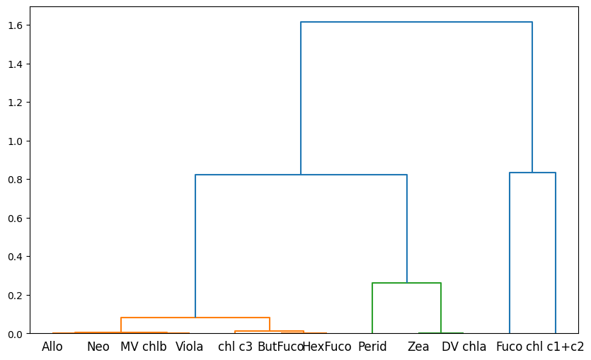

```python
import scipy.cluster.hierarchy as sch
from scipy.spatial.distance import squareform

keep_cols = [c for c in pigments_df.columns if c not in ['T chla', 'lon', 'lat', 'date']]

ratios = pigments_df[keep_cols].div(pigments_df['T chla'], axis=0) # 12 cols

corr = ratios.corr() # 12x12 symmetric matrix
dist = 1 - corr
condensed = squareform(dist, checks=False)
linkage = sch.linkage(condensed, method='ward')

clusters = sch.fcluster(linkage, t=0.65, criterion='distance')

fig, ax = plt.subplots(figsize=(10, 6))
sch.dendrogram(linkage, labels=keep_cols, ax=ax, color_threshold=0.40)
plt.show()
```

Ward's linkage is a bottom-up hierarchical clustering algorithm. Each data point starts as its own cluster, then repeatedly merges the two clusters whose merge causes the smallest increase in total within-cluster variance.

Within-cluster variance is $$\text{Var}(C) = \sum_{x_i \in C} |x_i - \bar{x}_C|^2$$ where $\bar{x}_C$ is that cluster's centroid.